# Regressing emissions from vehicle and road data

James David Smith

## Import Grid points

Import points which represent 1km grid centroids of a grid covering London

```r
grid        <- read.csv('X:/Projects/LAEI2013_TfL_Strategy/z_GridsForJames.csv')
grid        <- grid[,c('GridIdEx', 'Easting', 'Northing')]

names(grid) <- c('grid_exact_cut', 'easting', 'northing')
```

This gives a table of **3355 rows**, show below.

| grid_exact_cut | easting | northing |
| --- | --- | --- |
| 32 | 517500 | 201500 |
| 33 | 518500 | 201500 |
| 34 | 519500 | 201500 |
| 35 | 520500 | 201500 |
| 36 | 521500 | 201500 |
| 37 | 543500 | 201500 |

## Import Traffic flows

Now import traffic flows by toid and grid exact cut, and edit/clean to get what we need

```r
traffic_flows                 <- read.csv('X:/Projects/LAEI2013_Gdrive/TrafficFlows/Major_WithAdjustedIbus_AADT/z_AADT_ExactCut_WithIbus_2013.csv')
names(traffic_flows)          <- tolower(names(traffic_flows))

drop                          <- c('year', 'location_exactcut', 'boroughname_exactcut', 'tlrn', 'irr', 'motorwaynumber', 'petrolcar', 'dieselcar', 'electriccar', 'petrollgv', 'diesellgv', 'electriclgv', 'ltbus', 'coach')
traffic_flows                 <- traffic_flows[, !(names(traffic_flows) %in% drop)]

traffic_flows$toid            <- as.character(traffic_flows$toid)

traffic_flows$total_vehicles  <- (traffic_flows$motorcycle + traffic_flows$taxi + traffic_flows$car + traffic_flows$busandcoach + traffic_flows$lgv + traffic_flows$rigid2axle + traffic_flows$rigid3axle + traffic_flows$rigid4axle +     traffic_flows$artic3axle + traffic_flows$artic5axle + traffic_flows$artic6axle)

traffic_flows$total_light     <- (traffic_flows$motorcycle + traffic_flows$taxi + traffic_flows$car)

traffic_flows$total_heavy     <- (traffic_flows$busandcoach + traffic_flows$lgv + traffic_flows$rigid2axle + traffic_flows$rigid3axle + traffic_flows$rigid4axle + traffic_flows$artic3axle + traffic_flows$artic5axle + traffic_flows$artic6axle)

drop                          <- c('motorcycle', 'taxi', 'car', 'busandcoach', 'lgv', 'rigid2axle', 'rigid3axle', 'rigid4axle', 'artic3axle', 'artic5axle', 'artic6axle')
traffic_flows                 <- traffic_flows[, !(names(traffic_flows) %in% drop)]
```

This gives a table of **87996 rows**, show below.

| toid | grid_exactcut_id | dotref | id | speed | total_vehicles | total_light | total_heavy |
| --- | --- | --- | --- | --- | --- | --- | --- |
| 4000000030455238 | 2739 | 26145 | 0 | 48.92023 | 28315.654 | 23554.666 | 4760.9877 |
| 4000000030455245 | 2738 | 8468 | 0 | 59.23806 | 85580.440 | 68722.520 | 16857.9195 |
| 4000000030455249 | 2739 | 8468 | 0 | 13.03565 | 85580.440 | 68722.520 | 16857.9195 |
| 4000000030455250 | 2738 | 8468 | 0 | 27.10584 | 85580.440 | 68722.520 | 16857.9195 |
| 4000000030455254 | 818 | 0 | 13633 | 13.94029 | 4395.482 | 3897.315 | 498.1674 |
| 4000000030455271 | 2160 | 999957 | 0 | 30.18082 | 15938.228 | 13188.405 | 2749.8227 |

## Import TOID information

```r
road_info                    <- read.csv('erg_roads_info.csv')

names(road_info)             <- tolower(names(road_info))

road_info                    <- road_info[,c('toid', 'desc_term')]

road_info$toid               <- as.character(road_info$toid)
```

## Import Emissions

Import emissions by toid and grid exact cut

```r
emissions                     <- read.csv('X:/Projects/LAEI2013_TfL_Strategy/FilesForHerald4/EmissionsByLink/INPUT_RESULTS_LAEI_ExactCutIntersect_Major_2013_LAEI_V117.csv')
names(emissions)              <- tolower(names(emissions))

drop                          <- c('emissions', 'year', 'petrolcar', 'dieselcar', 'petrollgv', 'diesellgv', 'ltbus', 'coach', 'electriccar', 'electriclgv')
emissions                     <- emissions[, !(names(emissions) %in% drop)]

emissions$total_light_emissions     <- emissions$motorcycle + emissions$taxi + emissions$car

emissions$total_heavy_emissions     <- emissions$busandcoach + emissions$lgv + emissions$rigid + emissions$artic + emissions$rigid2axle + emissions$rigid3axle + emissions$rigid4axle + emissions$artic3axle + emissions$artic5axle + emissions$artic6axle

emissions$total_emissions     <- emissions$motorcycle + emissions$taxi + emissions$car + emissions$busandcoach + emissions$lgv + emissions$rigid + emissions$artic + emissions$rigid2axle + emissions$rigid3axle + emissions$rigid4axle + emissions$artic3axle + emissions$artic5axle + emissions$artic6axle

emissions$toid                <- as.character(emissions$toid)

drop                          <- c('motorcycle', 'taxi', 'car', 'busandcoach', 'lgv', 'rigid', 'artic', 'rigid2axle', 'rigid3axle', 'rigid4axle', 'artic3axle', 'artic5axle', 'artic6axle')
emissions                     <- emissions[, !(names(emissions) %in% drop)]

emissions                     <- emissions[!(emissions$pollutant %in% c('TB_PM10_SW', 'TB_PM25_SW')),]
```

Not going to need all the constiuent parts of the emissions, just the total by each. So aggregate up.

```r
emissions$pollutant           <- as.character(emissions$pollutant)

emissions[grep('pm25', tolower(emissions$pollutant)),'pollutant'] <- 'pm25'
emissions[grep('pm10', tolower(emissions$pollutant)),'pollutant'] <- 'pm10'

emissions$gridid            <- as.character(emissions$gridid)
emissions$grid_exactcut_id  <- as.character(emissions$grid_exactcut_id)
emissions$dotref            <- as.character(emissions$dotref)

emissions$pollutant         <- tolower(emissions$pollutant)

emissions <- aggregate(cbind(total_emissions, total_light_emissions, total_heavy_emissions) ~ gridid + toid + grid_exactcut_id + dotref + length + pollutant, data=emissions, FUN=sum)
```

This gives a table of **205496 rows**, show below.

| gridid | toid | grid_exactcut_id | dotref | length | pollutant | total_emissions | total_light_emissions | total_heavy_emissions |
| --- | --- | --- | --- | --- | --- | --- | --- | --- |
| 6772 | 4000000030098250 | 106 | 16001 | 0 | no2 | 0 | 0 | 0 |
| 6772 | 4000000030098253 | 106 | 16001 | 0 | no2 | 0 | 0 | 0 |
| 6772 | 4000000030413089 | 106 | 16001 | 0 | no2 | 0 | 0 | 0 |
| 6772 | 4000000030413092 | 106 | 16001 | 0 | no2 | 0 | 0 | 0 |
| 6083 | 4000000027909026 | 12 | 16001 | 0 | no2 | 0 | 0 | 0 |
| 6083 | 4000000027909034 | 12 | 16001 | 0 | no2 | 0 | 0 | 0 |

## Link traffic flows to road info

```r
traffic_flows             <- merge(traffic_flows, road_info, by.x = 'toid', by.y = 'toid')
rm(road_info)
```

## Link traffic flows to grids

```r
grid_traffic              <- merge(traffic_flows, grid, by.x = c('grid_exactcut_id'), by.y = c('grid_exact_cut'))
rm(traffic_flows)
grid_traffic              <- grid_traffic[order(grid_traffic$toid),]
```

Looks like this

|  | grid_exactcut_id | toid | dotref | id | speed | total_vehicles | total_light | total_heavy | desc_term | easting | northing |
| --- | --- | --- | --- | --- | --- | --- | --- | --- | --- | --- | --- |
| 421 | 27 | 4000000027865913 | 16001 | 0 | 98.99142 | 88097.16 | 72202.86 | 15894.29 | Motorway | 512500 | 201500 |
| 647 | 45 | 4000000027865913 | 16001 | 0 | 98.99142 | 88097.16 | 72202.86 | 15894.29 | Motorway | 512500 | 200500 |
| 1138 | 74 | 4000000027865913 | 16001 | 0 | 98.99142 | 88097.16 | 72202.86 | 15894.29 | Motorway | 512500 | 199500 |
| 1744 | 106 | 4000000027865913 | 16001 | 0 | 98.99142 | 88097.16 | 72202.86 | 15894.29 | Motorway | 512500 | 198500 |
| 423 | 27 | 4000000027865914 | 16001 | 0 | 103.32334 | 88097.16 | 72202.86 | 15894.29 | Motorway | 512500 | 201500 |
| 646 | 45 | 4000000027865914 | 16001 | 0 | 103.32334 | 88097.16 | 72202.86 | 15894.29 | Motorway | 512500 | 200500 |

Now take the mean traffic flow, on each toid, by grid square (using easting and northing)

```r
grid_traffic <- aggregate(data = grid_traffic, FUN=mean, cbind(speed, total_vehicles, total_light, total_heavy)~ easting+northing+toid+desc_term)
```

Now looks like this

|  | easting | northing | toid | desc_term | speed | total_vehicles | total_light | total_heavy |
| --- | --- | --- | --- | --- | --- | --- | --- | --- |
| 83724 | 512500 | 198500 | 4000000027865913 | Motorway | 98.99142 | 88097.16 | 72202.86 | 15894.29 |
| 83725 | 512500 | 199500 | 4000000027865913 | Motorway | 98.99142 | 88097.16 | 72202.86 | 15894.29 |
| 83726 | 512500 | 200500 | 4000000027865913 | Motorway | 98.99142 | 88097.16 | 72202.86 | 15894.29 |
| 83727 | 512500 | 201500 | 4000000027865913 | Motorway | 98.99142 | 88097.16 | 72202.86 | 15894.29 |
| 83728 | 512500 | 198500 | 4000000027865914 | Motorway | 103.32334 | 88097.16 | 72202.86 | 15894.29 |
| 83729 | 512500 | 199500 | 4000000027865914 | Motorway | 103.32334 | 88097.16 | 72202.86 | 15894.29 |

## Link emissions to grids

```r
emissions_grids              <- merge(emissions, grid, by.x = 'grid_exactcut_id', by.y = 'grid_exact_cut')
rm(emissions)
emissions_grids              <- emissions_grids[order(emissions_grids$toid),]
```

## Link emissions, to traffic, to grids

```r
all_data                <- merge(emissions_grids, grid_traffic, by.x = c('toid', 'easting', 'northing'), by.y = c('toid', 'easting', 'northing'))

rm(grid, grid_traffic, emissions_grids,drop)
```

Example of final data for NO2 and one grid

|  | toid | easting | northing | grid_exactcut_id | gridid | dotref | length | pollutant | total_emissions | total_light_emissions | total_heavy_emissions | desc_term | speed | total_vehicles | total_light | total_heavy |
| --- | --- | --- | --- | --- | --- | --- | --- | --- | --- | --- | --- | --- | --- | --- | --- | --- |
| 1 | 4000000027865913 | 512500 | 198500 | 106 | 6772 | 16001 | 51.510888 | no2 | 0.2727828 | 0.1238078 | 0.1489751 | Motorway | 98.99142 | 88097.16 | 72202.86 | 15894.294 |
| 20 | 4000000027865914 | 512500 | 198500 | 106 | 6772 | 16001 | 54.546206 | no2 | 0.2996166 | 0.1367628 | 0.1628538 | Motorway | 103.32334 | 88097.16 | 72202.86 | 15894.294 |
| 14865 | 4000000030098250 | 512500 | 198500 | 106 | 6772 | 16001 | 0.000000 | no2 | 0.0000000 | 0.0000000 | 0.0000000 | Motorway | 66.71721 | 88097.16 | 72202.86 | 15894.294 |
| 14869 | 4000000030098251 | 512500 | 198500 | 106 | 6772 | 16001 | 188.781649 | no2 | 1.0677528 | 0.4903685 | 0.5773844 | Motorway | 105.79689 | 88097.16 | 72202.86 | 15894.294 |
| 14875 | 4000000030098252 | 512500 | 198500 | 106 | 6772 | 16001 | 185.253756 | no2 | 1.0116819 | 0.4622552 | 0.5494268 | Motorway | 102.87508 | 88097.16 | 72202.86 | 15894.294 |
| 14877 | 4000000030098253 | 512500 | 198500 | 106 | 6772 | 16001 | 0.000000 | no2 | 0.0000000 | 0.0000000 | 0.0000000 | Motorway | 29.00185 | 88097.16 | 72202.86 | 15894.294 |
| 14881 | 4000000030098254 | 512500 | 198500 | 106 | 6772 | 26461 | 0.000000 | no2 | 0.0000000 | 0.0000000 | 0.0000000 | A Road | 60.32731 | 33932.38 | 29294.97 | 4637.408 |
| 14888 | 4000000030098255 | 512500 | 198500 | 106 | 6772 | 26461 | 144.506411 | no2 | 0.2242166 | 0.1193315 | 0.1048852 | A Road | 73.37013 | 33932.38 | 29294.97 | 4637.408 |
| 14891 | 4000000030098256 | 512500 | 198500 | 106 | 6772 | 26461 | 147.787159 | no2 | 0.2247083 | 0.1197292 | 0.1049791 | A Road | 81.29693 | 33932.38 | 29294.97 | 4637.408 |
| 14895 | 4000000030098257 | 512500 | 198500 | 106 | 6772 | 26461 | 0.000000 | no2 | 0.0000000 | 0.0000000 | 0.0000000 | A Road | 26.40186 | 33932.38 | 29294.97 | 4637.408 |
| 14897 | 4000000030098264 | 512500 | 198500 | 106 | 6772 | 16001 | 152.961181 | no2 | 0.8243357 | 0.3746382 | 0.4496975 | Motorway | 101.59566 | 88097.16 | 72202.86 | 15894.294 |
| 14904 | 4000000030098265 | 512500 | 198500 | 106 | 6772 | 16001 | 151.508332 | no2 | 0.7772227 | 0.3494593 | 0.4277634 | Motorway | 96.02209 | 88097.16 | 72202.86 | 15894.294 |
| 14907 | 4000000030098266 | 512500 | 198500 | 106 | 6772 | 26461 | 221.933185 | no2 | 0.4558797 | 0.2298729 | 0.2260068 | A Road | 34.06254 | 33932.38 | 29294.97 | 4637.408 |
| 14918 | 4000000030098273 | 512500 | 198500 | 106 | 6772 | 36001 | 35.607109 | no2 | 0.2035174 | 0.0874921 | 0.1160252 | Motorway | 103.17324 | 88111.81 | 70593.34 | 17518.467 |
| 14927 | 4000000030098274 | 512500 | 198500 | 106 | 6772 | 36001 | 0.000000 | no2 | 0.0000000 | 0.0000000 | 0.0000000 | Motorway | 76.95585 | 88111.81 | 70593.34 | 17518.467 |
| 28980 | 4000000030141133 | 512500 | 198500 | 106 | 6772 | 26461 | 182.812383 | no2 | 0.2738319 | 0.1430747 | 0.1307571 | A Road | 71.60664 | 33932.38 | 29294.97 | 4637.408 |
| 28984 | 4000000030141138 | 512500 | 198500 | 106 | 6772 | 26461 | 130.948457 | no2 | 0.2826997 | 0.1411773 | 0.1415224 | A Road | 34.74561 | 33932.38 | 29294.97 | 4637.408 |
| 28992 | 4000000030141139 | 512500 | 198500 | 106 | 6772 | 26461 | 104.652015 | no2 | 0.1726599 | 0.0881607 | 0.0844993 | A Road | 51.89077 | 33932.38 | 29294.97 | 4637.408 |
| 29016 | 4000000030141186 | 512500 | 198500 | 106 | 6772 | 36001 | 0.000000 | no2 | 0.0000000 | 0.0000000 | 0.0000000 | Motorway | 36.06457 | 88111.81 | 70593.34 | 17518.467 |
| 29023 | 4000000030141187 | 512500 | 198500 | 106 | 6772 | 36001 | 42.712267 | no2 | 0.2547503 | 0.1105538 | 0.1441965 | Motorway | 106.96976 | 88111.81 | 70593.34 | 17518.467 |
| 29036 | 4000000030141188 | 512500 | 198500 | 106 | 6772 | 6456 | 0.000000 | no2 | 0.0000000 | 0.0000000 | 0.0000000 | A Road | 21.84710 | 46901.22 | 41064.90 | 5836.322 |
| 29047 | 4000000030141189 | 512500 | 198500 | 106 | 6772 | 6456 | 61.520737 | no2 | 0.1216399 | 0.0702936 | 0.0513463 | A Road | 81.21151 | 46901.22 | 41064.90 | 5836.322 |
| 29060 | 4000000030141190 | 512500 | 198500 | 106 | 6772 | 6456 | 67.537773 | no2 | 0.1320438 | 0.0756904 | 0.0563534 | A Road | 76.09839 | 46901.22 | 41064.90 | 5836.322 |
| 29072 | 4000000030141191 | 512500 | 198500 | 106 | 6772 | 6456 | 0.000000 | no2 | 0.0000000 | 0.0000000 | 0.0000000 | A Road | 51.13605 | 46901.22 | 41064.90 | 5836.322 |
| 55288 | 4000000030227179 | 512500 | 198500 | 106 | 6772 | 26461 | 65.764735 | no2 | 0.1003584 | 0.0534894 | 0.0468690 | A Road | 79.59250 | 33932.38 | 29294.97 | 4637.408 |
| 55290 | 4000000030227180 | 512500 | 198500 | 106 | 6772 | 26461 | 65.408333 | no2 | 0.0997009 | 0.0532019 | 0.0464990 | A Road | 82.01272 | 33932.38 | 29294.97 | 4637.408 |
| 55300 | 4000000030227181 | 512500 | 198500 | 106 | 6772 | 26461 | 2.826270 | no2 | 0.0066291 | 0.0032396 | 0.0033895 | A Road | 30.47028 | 33932.38 | 29294.97 | 4637.408 |
| 55301 | 4000000030227190 | 512500 | 198500 | 106 | 6772 | 26461 | 50.609063 | no2 | 0.0831328 | 0.0422528 | 0.0408800 | A Road | 51.06479 | 33932.38 | 29294.97 | 4637.408 |
| 55318 | 4000000030227243 | 512500 | 198500 | 106 | 6772 | 36001 | 63.913122 | no2 | 0.3796453 | 0.1644609 | 0.2151845 | Motorway | 106.99156 | 88111.81 | 70593.34 | 17518.467 |
| 55322 | 4000000030227244 | 512500 | 198500 | 106 | 6772 | 36001 | 62.850492 | no2 | 0.3587555 | 0.1540971 | 0.2046583 | Motorway | 103.22376 | 88111.81 | 70593.34 | 17518.467 |
| 91746 | 4000000030333096 | 512500 | 198500 | 106 | 6772 | 26461 | 33.276764 | no2 | 0.1065320 | 0.0486165 | 0.0579155 | A Road | 12.54503 | 33932.38 | 29294.97 | 4637.408 |
| 125577 | 4000000030413089 | 512500 | 198500 | 106 | 6772 | 16001 | 0.000000 | no2 | 0.0000000 | 0.0000000 | 0.0000000 | Motorway | 87.21668 | 88097.16 | 72202.86 | 15894.294 |
| 125583 | 4000000030413090 | 512500 | 198500 | 106 | 6772 | 16001 | 11.496550 | no2 | 0.0648114 | 0.0297607 | 0.0350506 | Motorway | 105.77143 | 88097.16 | 72202.86 | 15894.294 |
| 125586 | 4000000030413091 | 512500 | 198500 | 106 | 6772 | 16001 | 11.741428 | no2 | 0.0640695 | 0.0292958 | 0.0347737 | Motorway | 102.86827 | 88097.16 | 72202.86 | 15894.294 |
| 125589 | 4000000030413092 | 512500 | 198500 | 106 | 6772 | 16001 | 0.000000 | no2 | 0.0000000 | 0.0000000 | 0.0000000 | Motorway | 77.77912 | 88097.16 | 72202.86 | 15894.294 |
| 125596 | 4000000030413098 | 512500 | 198500 | 106 | 6772 | 26461 | 0.000000 | no2 | 0.0000000 | 0.0000000 | 0.0000000 | A Road | 77.12659 | 33932.38 | 29294.97 | 4637.408 |
| 148396 | 4000000030456485 | 512500 | 198500 | 106 | 6772 | 26461 | 7.071063 | no2 | 0.0107419 | 0.0057210 | 0.0050209 | A Road | 81.16264 | 33932.38 | 29294.97 | 4637.408 |
| 159078 | 4000000030474524 | 512500 | 198500 | 106 | 6772 | 26461 | 3.434188 | no2 | 0.0054304 | 0.0028584 | 0.0025720 | A Road | 63.76062 | 33932.38 | 29294.97 | 4637.408 |
| 168594 | 4000000030757876 | 512500 | 198500 | 106 | 6772 | 26461 | 18.034695 | no2 | 0.0287095 | 0.0151375 | 0.0135720 | A Road | 63.86696 | 33932.38 | 29294.97 | 4637.408 |
| 200373 | 4000000031239134 | 512500 | 198500 | 106 | 6772 | 26461 | 4.869538 | no2 | 0.0095019 | 0.0047475 | 0.0047543 | A Road | 36.15354 | 33932.38 | 29294.97 | 4637.408 |
| 200391 | 4000000031239138 | 512500 | 198500 | 106 | 6772 | 26461 | 5.024591 | no2 | 0.0097761 | 0.0049068 | 0.0048693 | A Road | 35.98589 | 33932.38 | 29294.97 | 4637.408 |

## Aggregate 1km grids to 10km

First sum emissions by the 1km, to 1km grid, and create raster stacks from them

```r
ukgrid = "+init=epsg:27700"

one_km_emissions <- aggregate(data = all_data, total_emissions ~ pollutant + easting + northing, FUN=sum)

sources          <- as.character((unique(one_km_emissions$pollutant)))

for (i in 1:length(sources)) {

  temp              <- one_km_emissions[one_km_emissions$pollutant == sources[i],]
  coordinates(temp) <- ~ easting + northing
  temp$pollutant    <- NULL
  gridded(temp)     <- TRUE
  proj4string(temp) <- CRS(ukgrid)
  temp              <- raster(temp)
  names(temp)       <- tolower(sources[i])

  if (i == 1) { one_km_emissions_raster <- temp} else {one_km_emissions_raster <- stack(one_km_emissions_raster, temp)}

}
```

**NO2 1km plot**

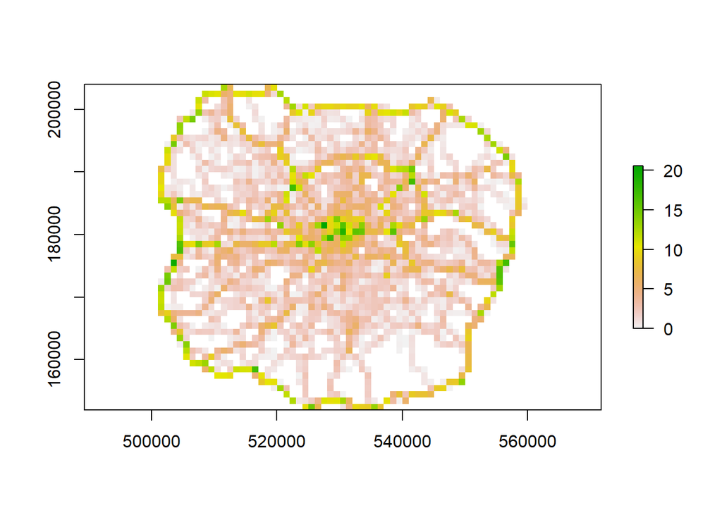

Now make a 10km plot

```r
ten_km_emissions_raster  <- aggregate(one_km_emissions_raster, fact = 10, fun=sum)

rm(one_km_emissions, one_km_emissions_raster, temp, i)
```

**NO2 10km plot**

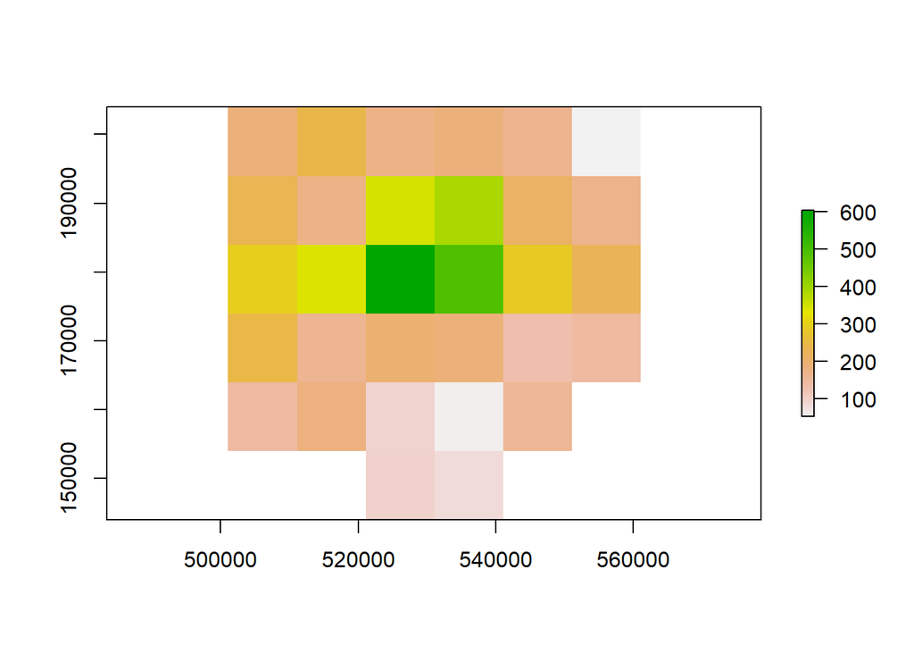

Now need to think about how these concentrations at 10km level, relate to the road link that contributed them, and get the relationship between them. First convert the raster to polygons.

```r
ten_km_emissions_polygons <- rasterToPolygons(ten_km_emissions_raster)
```

**NO2 10km polygons plot**

[interactive chart not shown]

## Link TOIDS to 10km grids

Turn the originl data into points, so that can use these to extract the values from the 10km polygons

```r
coordinates(all_data)           <- ~ easting + northing
proj4string(all_data)           <- CRS(ukgrid)
```

## Calculate each TOIDS contribution

This code now looks at each road, sees which overall 10km grid it is in, and then divides each pollutant by the total of that pollutant in the square. Puts the result into ‘ten_km_contribution’ variable.

```r
ten_km_emissions_polygons$id                            <- row.names(ten_km_emissions_polygons)

result                                                  <- point.in.poly(all_data, ten_km_emissions_polygons)

result                                                  <- data.frame(result)

result$ten_km_contribution                              <- NA

result[result$pollutant == 'no2',]$ten_km_contribution    <- result[result$pollutant == 'no2',]$total_emissions    / result[result$pollutant == 'no2',]$no2

result[result$pollutant == 'nox',]$ten_km_contribution    <- result[result$pollutant == 'nox',]$total_emissions    / result[result$pollutant == 'nox',]$nox

result[result$pollutant == 'pm10',]$ten_km_contribution   <- result[result$pollutant == 'pm10',]$total_emissions   / result[result$pollutant == 'pm10',]$pm10

result[result$pollutant == 'pm25',]$ten_km_contribution   <- result[result$pollutant == 'pm25',]$total_emissions   / result[result$pollutant == 'pm25',]$pm25

rm(all_data)
```

Some toid exact cuts (9616) have zero emissions, remove those from the total of 205496.

```r
result <- result[result$total_emissions > 0,]
```

Now before create a model to calculate a regression between the variables and the emissions, aggregate from TOID exact cuts, up to DotRef. This means that we go from 48970 ‘streets’ …..

```r
# Decided thsi wasn't needed
#result <- merge(
#          aggregate(data = result, cbind(length, total_emissions, ten_km_contribution) ~ dotref + desc_term + pollutant, sum),
#          aggregate(data = result, cbind(speed, total_vehicles, total_light, total_heavy) ~ dotref + desc_term + pollutant, mean),
#          by = c('dotref', 'pollutant', 'desc_term'))
```

… down to 48970.

## Exploring data relationships

### Histogram of 10km emission contributions

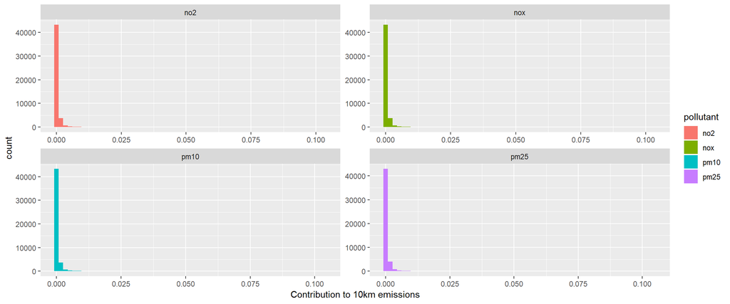

```r
ggplot(result, aes(ten_km_contribution)) +
  geom_histogram(bins = 60, aes(fill=pollutant)) +
  facet_wrap(.~pollutant, scales = 'free') +
  xlab('Contribution to 10km emissions')
```

### Total vehicles v. emission contribution

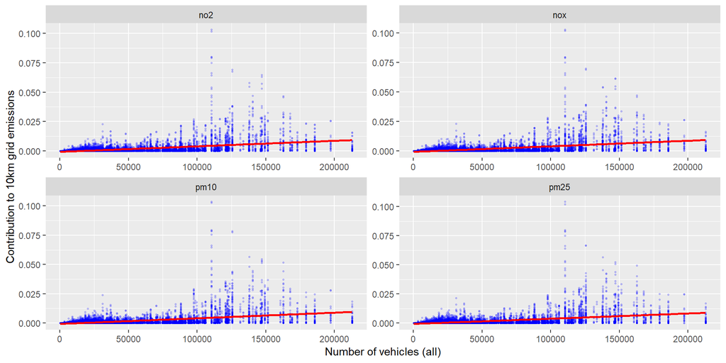

### Light vehicles v. emission contribution

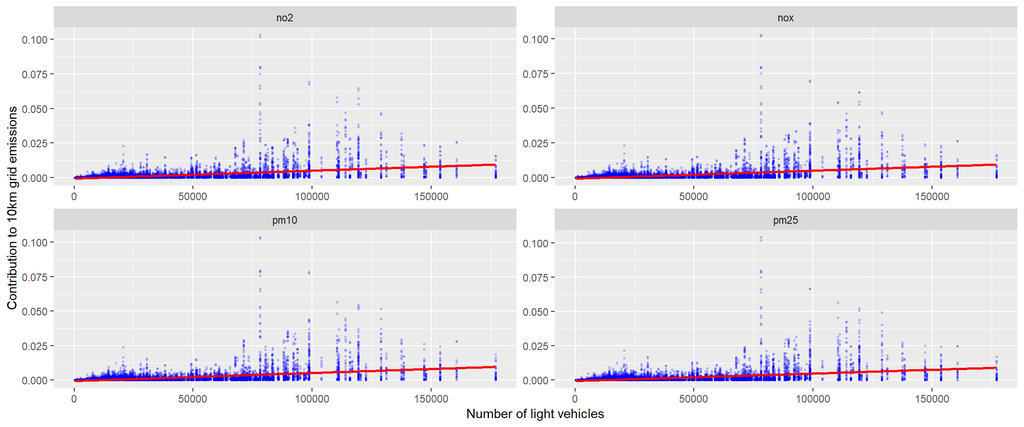

### Heavy vehicles v. emission contribution

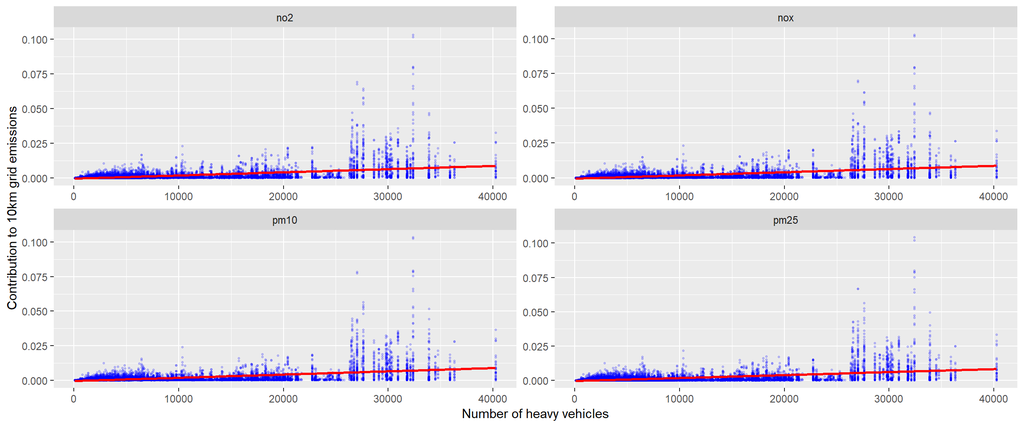

### Speed v. emission contribution

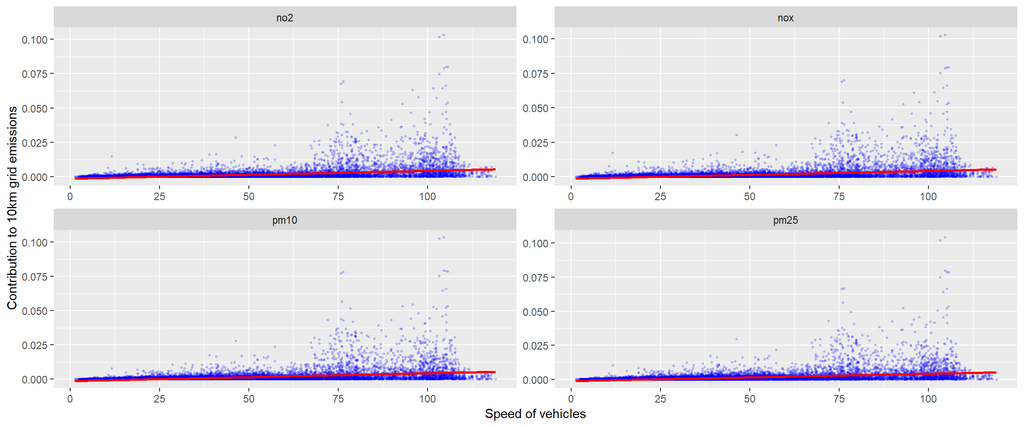

### Length v. emission contribution

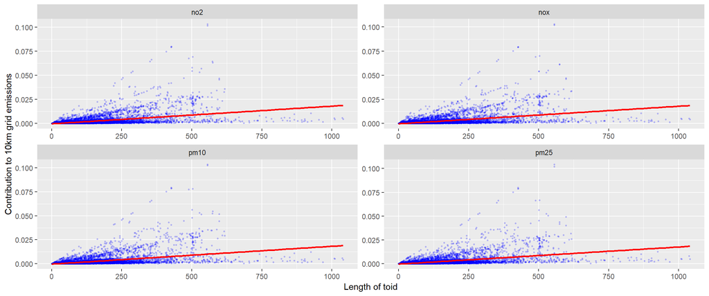

## Remove roads of very small number

```r
result <- result[!(result$desc_term %in% c('Alley', 'Private Road - Publicly Accessible', 'Pedestrianised Street')),]
```

## Create training and testing data

Take 80% of the data as a training data set

```r
training_index <- sample(nrow(result), round(nrow(result) * 0.8,0))

training_data <- result[training_index,]
```

Seperate the other 20% as a testing data set

```r
testing_data <- result[-training_index,]
```

## Make linear regression model

Make a liner regression model using the training data

```r
light_models <- list()
heavy_models <- list()

light_counter <- 1
heavy_counter <- 1

models_counter <- 1

road_types      <- unique(as.character(training_data$desc_term))

model_results <- data.frame(light_or_heavy = NA,
                            pollutant = NA,
                            rsquared = NA,
                            stringsAsFactors = F)

for (i in 1:length(sources)) {

  light_model <- lm(total_light_emissions ~ total_light*speed*length + desc_term,
             data=training_data[training_data$pollutant == sources[i],])

  heavy_model <- lm(total_heavy_emissions ~ total_heavy*speed*length + desc_term,
             data=training_data[training_data$pollutant == sources[i],])

  light_models[[light_counter]] <- light_model

  heavy_models[[heavy_counter]] <- heavy_model

  model_results[models_counter,] <- c('light', sources[i],  round(summary(light_model)$adj.r.squared,5) )

  models_counter <- models_counter + 1

  model_results[models_counter,] <- c('heavy', sources[i],  round(summary(heavy_model)$adj.r.squared,5) )

  models_counter <- models_counter + 1

  light_counter <- light_counter + 1
  heavy_counter <- heavy_counter + 1

}

rm(light_counter, heavy_counter, models_counter, light_model, heavy_model)
```

## Model result

```r
kable(model_results)%>% kable_styling(bootstrap_options = c("striped", "hover", "condensed", "responsive"), full_width = F, position = "left")
```

| light_or_heavy | pollutant | rsquared |
| --- | --- | --- |
| light | no2 | 0.98654 |
| heavy | no2 | 0.96833 |
| light | nox | 0.99342 |
| heavy | nox | 0.95654 |
| light | pm10 | 0.99712 |
| heavy | pm10 | 0.96444 |
| light | pm25 | 0.99599 |
| heavy | pm25 | 0.97652 |

## Apply linear regression model

Now use the regression equation on the testing 20% data

```r
testing_data$light_emissions_prediction <- NA
testing_data$heavy_emissions_prediction <- NA

for (i in 1:length(sources)) {

  testing_data[testing_data$pollutant == sources[i],'light_emissions_prediction'] <-   predict(light_models[[i]], testing_data[testing_data$pollutant == sources[i],])

  testing_data[testing_data$pollutant == sources[i],'heavy_emissions_prediction'] <-   predict(heavy_models[[i]], testing_data[testing_data$pollutant == sources[i],])

  }

testing_data$total_emissions_prediction <- testing_data$light_emissions_prediction + testing_data$heavy_emissions_prediction
```

## Results

Plot the prediction against the actuals for the testing 20%

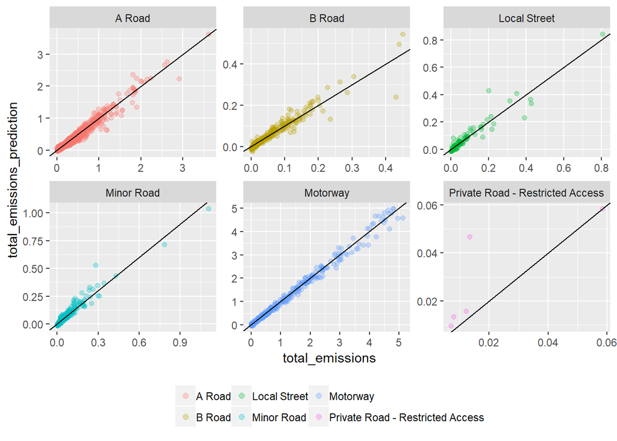

```r
no2
```

```r
modStats(testing_data[testing_data$pollutant == 'no2',], mod = 'total_emissions_prediction', obs = 'total_emissions')
```

```
##    default    n      FAC2           MB       MGE          NMB      NMGE
## 1 all data 9909 0.8984761 7.676072e-05 0.0179345 0.0005692127 0.1329918
##         RMSE         r       COE       IOA
## 1 0.03973069 0.9936747 0.8764331 0.9382166
```

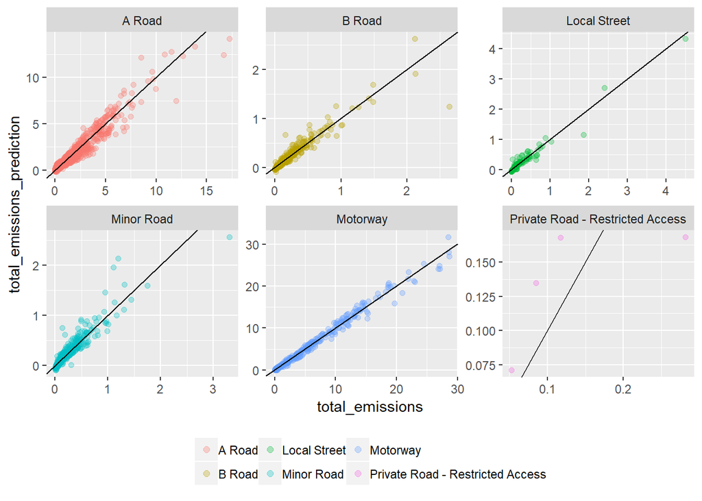

```r
nox
```

```r
modStats(testing_data[testing_data$pollutant == 'nox',], mod = 'total_emissions_prediction', obs = 'total_emissions')
```

```
##    default    n      FAC2           MB        MGE          NMB      NMGE
## 1 all data 9743 0.8941804 -0.002434774 0.09883365 -0.003794476 0.1540274
##        RMSE         r       COE       IOA
## 1 0.2349583 0.9907803 0.8582211 0.9291106
```

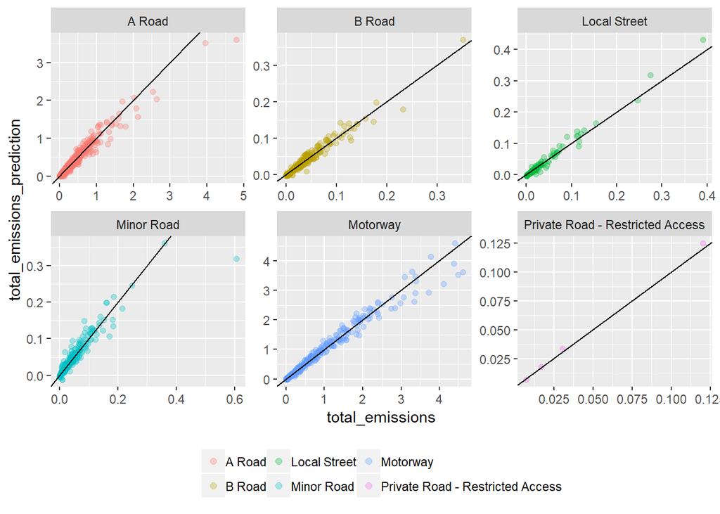

```r
pm10
```

```r
modStats(testing_data[testing_data$pollutant == 'pm10',], mod = 'total_emissions_prediction', obs = 'total_emissions')
```

```
##    default    n      FAC2            MB       MGE          NMB      NMGE
## 1 all data 9690 0.8841073 -0.0004456254 0.0110615 -0.005034018 0.1249565
##         RMSE         r       COE       IOA
## 1 0.03978195 0.9883926 0.8882191 0.9441096
```

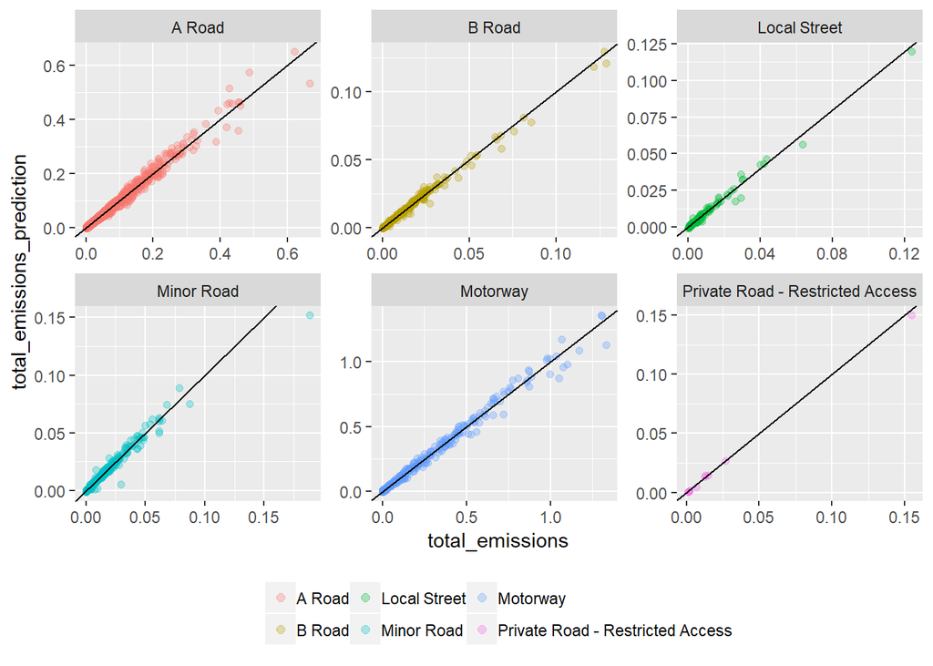

```r
pm25
```

```r
modStats(testing_data[testing_data$pollutant == 'pm25',], mod = 'total_emissions_prediction', obs = 'total_emissions')
```

```
##    default    n      FAC2            MB         MGE           NMB
## 1 all data 9829 0.9603215 -1.752471e-05 0.001975805 -0.0006268849
##         NMGE        RMSE         r       COE       IOA
## 1 0.07067749 0.006798929 0.9957617 0.9326886 0.9663443
```

So this regression model (light_vehicles * speed * length + desc_term), gives us a way of estimating emissions on a road based on the total_vehicles, speed, length and type of road. Using this we can estimate the emissions in a 10km grid, then look at the EMEP emissions for that 10km, and scale our calculated emissions down or up.

Taking this model, let’s see how it works on traffic and emissions for 2025.

```r
grid        <- read.csv('X:/Projects/LAEI2013_TfL_Strategy/z_GridsForJames.csv')
grid        <- grid[,c('GridIdEx', 'Easting', 'Northing')]

names(grid) <- c('grid_exact_cut', 'easting', 'northing')

###

traffic_flows                 <- read.csv('X:/Projects/LAEI2013_TfL_Strategy/FilesForHerald4/TrafficFlows/Major_WithAdjustedIbus_AADT/z_AADT_ExactCut_WithIbus_v1201_2025.csv')
names(traffic_flows)          <- tolower(names(traffic_flows))

drop                          <- c('year', 'location_exactcut', 'boroughname_exactcut', 'tlrn', 'irr', 'motorwaynumber', 'petrolcar', 'dieselcar', 'electriccar', 'petrollgv', 'diesellgv', 'electriclgv', 'ltbus', 'coach')
traffic_flows                 <- traffic_flows[, !(names(traffic_flows) %in% drop)]

traffic_flows$toid            <- as.character(traffic_flows$toid)

traffic_flows$total_vehicles  <- (traffic_flows$motorcycle + traffic_flows$taxi + traffic_flows$car + traffic_flows$busandcoach + traffic_flows$lgv + traffic_flows$rigid2axle + traffic_flows$rigid3axle + traffic_flows$rigid4axle +     traffic_flows$artic3axle + traffic_flows$artic5axle + traffic_flows$artic6axle)

traffic_flows$total_light     <- (traffic_flows$motorcycle + traffic_flows$taxi + traffic_flows$car)

traffic_flows$total_heavy     <- (traffic_flows$busandcoach + traffic_flows$lgv + traffic_flows$rigid2axle + traffic_flows$rigid3axle + traffic_flows$rigid4axle + traffic_flows$artic3axle + traffic_flows$artic5axle + traffic_flows$artic6axle)

drop                          <- c('motorcycle', 'taxi', 'car', 'busandcoach', 'lgv', 'rigid2axle', 'rigid3axle', 'rigid4axle', 'artic3axle', 'artic5axle', 'artic6axle')
traffic_flows                 <- traffic_flows[, !(names(traffic_flows) %in% drop)]

###

road_info                    <- read.csv('erg_roads_info.csv')

names(road_info)             <- tolower(names(road_info))

road_info                    <- road_info[,c('toid', 'desc_term')]

road_info$toid               <- as.character(road_info$toid)

####

emissions                     <- read.csv('X:/Projects/LAEI2013_TfL_Strategy/FilesForHerald4/EmissionsByLink/INPUT_RESULTS_LAEI_ExactCutIntersect_Major_2025_LAEI_v12019.csv')
names(emissions)              <- tolower(names(emissions))

drop                          <- c('emissions', 'year', 'petrolcar', 'dieselcar', 'petrollgv', 'diesellgv', 'ltbus', 'coach', 'electriccar', 'electriclgv')
emissions                     <- emissions[, !(names(emissions) %in% drop)]

emissions$total_light_emissions     <- emissions$motorcycle + emissions$taxi + emissions$car

emissions$total_heavy_emissions     <- emissions$busandcoach + emissions$lgv + emissions$rigid + emissions$artic + emissions$rigid2axle + emissions$rigid3axle + emissions$rigid4axle + emissions$artic3axle + emissions$artic5axle + emissions$artic6axle

emissions$total_emissions     <- emissions$motorcycle + emissions$taxi + emissions$car + emissions$busandcoach + emissions$lgv + emissions$rigid + emissions$artic + emissions$rigid2axle + emissions$rigid3axle + emissions$rigid4axle + emissions$artic3axle + emissions$artic5axle + emissions$artic6axle

emissions$toid                <- as.character(emissions$toid)

drop                          <- c('motorcycle', 'taxi', 'car', 'busandcoach', 'lgv', 'rigid', 'artic', 'rigid2axle', 'rigid3axle', 'rigid4axle', 'artic3axle', 'artic5axle', 'artic6axle')
emissions                     <- emissions[, !(names(emissions) %in% drop)]

emissions                     <- emissions[!(emissions$pollutant %in% c('TB_PM10_SW', 'TB_PM25_SW')),]

###

emissions$pollutant           <- as.character(emissions$pollutant)

emissions[grep('pm25', tolower(emissions$pollutant)),'pollutant'] <- 'pm25'
emissions[grep('pm10', tolower(emissions$pollutant)),'pollutant'] <- 'pm10'

emissions$gridid            <- as.character(emissions$gridid)
emissions$grid_exactcut_id  <- as.character(emissions$grid_exactcut_id)
emissions$dotref            <- as.character(emissions$dotref)

emissions$pollutant         <- tolower(emissions$pollutant)

emissions <- aggregate(cbind(total_emissions, total_light_emissions, total_heavy_emissions) ~ gridid + toid + grid_exactcut_id + dotref + length + pollutant, data=emissions, FUN=sum)

emissions <- emissions[emissions$total_emissions > 0,]

##

traffic_flows             <- merge(traffic_flows, road_info, by.x = 'toid', by.y = 'toid')
rm(road_info)

##

grid_traffic              <- merge(traffic_flows, grid, by.x = c('grid_exactcut_id'), by.y = c('grid_exact_cut'))
rm(traffic_flows)
grid_traffic              <- grid_traffic[order(grid_traffic$toid),]

##
emissions_grids              <- merge(emissions, grid, by.x = 'grid_exactcut_id', by.y = 'grid_exact_cut')
rm(emissions)
emissions_grids              <- emissions_grids[order(emissions_grids$toid),]

##

all_data                <- merge(emissions_grids, grid_traffic, by.x = c('toid', 'easting', 'northing'), by.y = c('toid', 'easting', 'northing'))

rm(grid, grid_traffic, emissions_grids,drop)

##
all_data <- all_data[!(all_data$desc_term %in% c('Alley', 'Private Road - Publicly Accessible', 'Pedestrianised Street')),]
all_data <- all_data[all_data$pollutant %in% sources,]

###

all_data$light_emissions_prediction <- NA
all_data$heavy_emissions_prediction <- NA
all_data$total_emissions_prediction <- NA

for (i in 1:length(sources)) {

  light_scaling_factor <- sum(all_data[all_data$pollutant == sources[i] ,'total_light_emissions']) /
                          sum(result[result$pollutant     == sources[i] ,'total_light_emissions'])

  heavy_scaling_factor <- sum(all_data[all_data$pollutant == sources[i] ,'total_heavy_emissions']) /
                          sum(result[result$pollutant     == sources[i] ,'total_heavy_emissions'])

  all_data[all_data$pollutant == sources[i],'light_emissions_prediction'] <-   predict(light_models[[i]], all_data[all_data$pollutant == sources[i],])*light_scaling_factor
  all_data[all_data$pollutant == sources[i],'heavy_emissions_prediction'] <-   predict(heavy_models[[i]], all_data[all_data$pollutant == sources[i],])*heavy_scaling_factor


}

all_data$total_emissions_prediction <- all_data$light_emissions_prediction*light_scaling_factor + all_data$heavy_emissions_prediction

##

##
no2 <- ggplot(all_data[all_data$pollutant == 'no2',], aes(total_emissions, total_emissions_prediction)) +
  geom_point(size=2, alpha=0.3, aes(colour=desc_term, stroke=0)) +
  theme(legend.position="bottom",
        legend.title = element_blank()) +
  facet_wrap(.~desc_term, scales='free') +
  geom_abline(slope=1, intercept=0)

nox <- ggplot(all_data[all_data$pollutant == 'nox',], aes(total_emissions, total_emissions_prediction)) +
  geom_point(size=2, alpha=0.3, aes(colour=desc_term, stroke=0)) +
  theme(legend.position="bottom",
        legend.title = element_blank()) +
  facet_wrap(.~desc_term, scales='free') +
  geom_abline(slope=1, intercept=0)

pm10 <- ggplot(all_data[all_data$pollutant == 'pm10',], aes(total_emissions, total_emissions_prediction)) +
  geom_point(size=2, alpha=0.3, aes(colour=desc_term, stroke=0)) +
  theme(legend.position="bottom",
        legend.title = element_blank()) +
  facet_wrap(.~desc_term, scales='free') +
  geom_abline(slope=1, intercept=0)

pm25 <- ggplot(all_data[all_data$pollutant == 'pm25',], aes(total_emissions, total_emissions_prediction)) +
  geom_point(size=2, alpha=0.3, aes(colour=desc_term, stroke=0)) +
  theme(legend.position="bottom",
        legend.title = element_blank()) +
  facet_wrap(.~desc_term, scales='free') +
  geom_abline(slope=1, intercept=0)
```

### 2025 Predictions

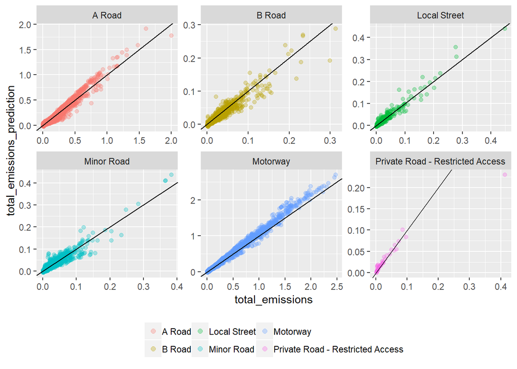

```r
no2
```

```r
kable(modStats(all_data[all_data$pollutant == 'no2',], mod = 'total_emissions_prediction', obs = 'total_emissions'))  %>% kable_styling(bootstrap_options = c("striped", "hover", "condensed", "responsive"), full_width = F, position = "left")
```

| default | n | FAC2 | MB | MGE | NMB | NMGE | RMSE | r | COE | IOA |
| --- | --- | --- | --- | --- | --- | --- | --- | --- | --- | --- |
| all data | 50962 | 0.8895648 | 0.0013934 | 0.0080128 | 0.0268406 | 0.1543529 | 0.0195612 | 0.9934346 | 0.8547117 | 0.9273558 |

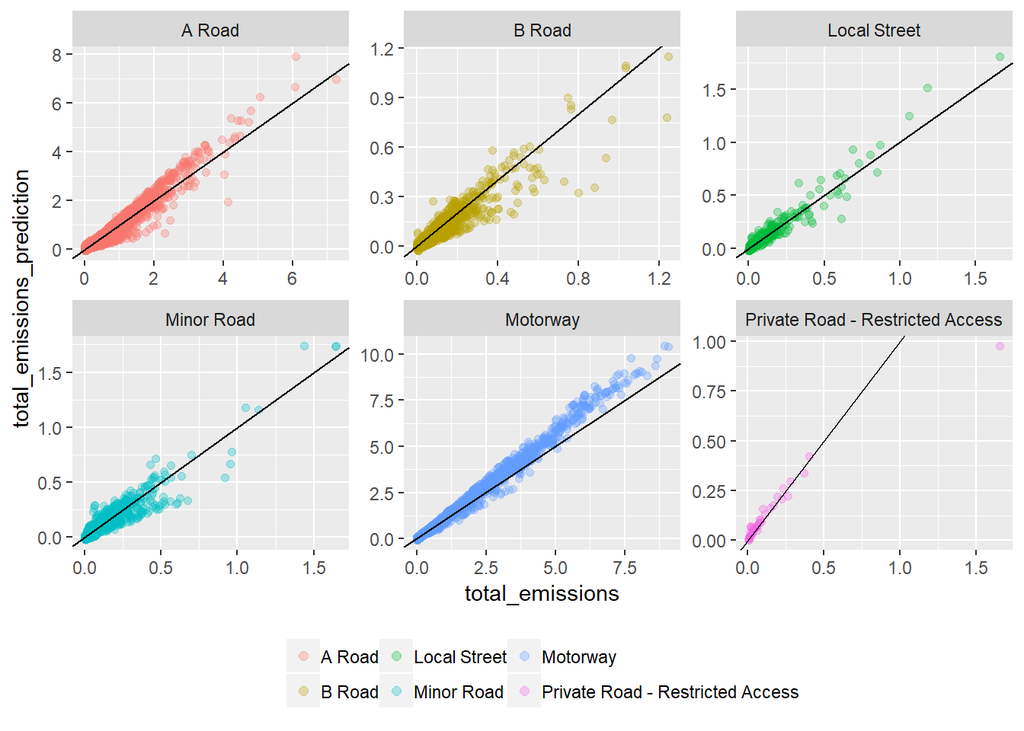

```r
nox
```

```r
kable(modStats(all_data[all_data$pollutant == 'nox',], mod = 'total_emissions_prediction', obs = 'total_emissions'))  %>% kable_styling(bootstrap_options = c("striped", "hover", "condensed", "responsive"), full_width = F, position = "left")
```

| default | n | FAC2 | MB | MGE | NMB | NMGE | RMSE | r | COE | IOA |
| --- | --- | --- | --- | --- | --- | --- | --- | --- | --- | --- |
| all data | 50962 | 0.8812841 | 0.0092556 | 0.0384156 | 0.0457109 | 0.1897243 | 0.0995792 | 0.9906517 | 0.8197602 | 0.9098801 |

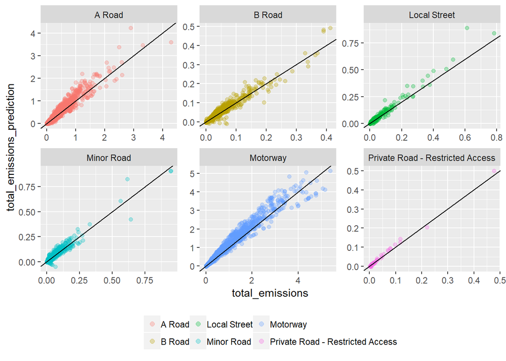

```r
pm10
```

```r
kable(modStats(all_data[all_data$pollutant == 'pm10',], mod = 'total_emissions_prediction', obs = 'total_emissions'))  %>% kable_styling(bootstrap_options = c("striped", "hover", "condensed", "responsive"), full_width = F, position = "left")
```

| default | n | FAC2 | MB | MGE | NMB | NMGE | RMSE | r | COE | IOA |
| --- | --- | --- | --- | --- | --- | --- | --- | --- | --- | --- |
| all data | 50962 | 0.8944704 | 0.0092249 | 0.0151642 | 0.1135611 | 0.1866766 | 0.0528928 | 0.9850918 | 0.8340267 | 0.9170133 |

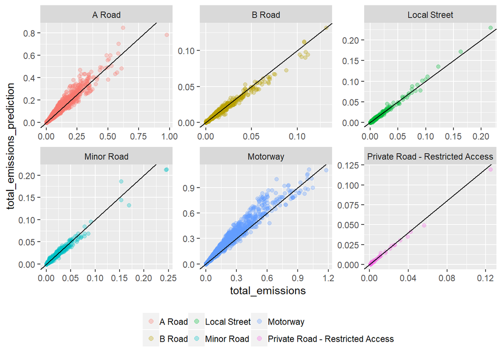

```r
pm25
```

```r
kable(modStats(all_data[all_data$pollutant == 'pm25',], mod = 'total_emissions_prediction', obs = 'total_emissions'))  %>% kable_styling(bootstrap_options = c("striped", "hover", "condensed", "responsive"), full_width = F, position = "left")
```

| default | n | FAC2 | MB | MGE | NMB | NMGE | RMSE | r | COE | IOA |
| --- | --- | --- | --- | --- | --- | --- | --- | --- | --- | --- |
| all data | 50962 | 0.9605588 | 0.0012928 | 0.0029851 | 0.0621238 | 0.1434511 | 0.0122593 | 0.9837408 | 0.863767 | 0.9318835 |